# Richmond Regional Housing Framework Data Update

Selected draft findings

HDAdvisors

2022-09-08

## Research scope

*How have housing needs changed across the region since the original Framework release?*

Four parts:

1. Demographic and socioeconomic changes
2. Housing supply and market changes
3. Gap analysis
4. Local summaries

## Data source updates

| Source | Original | Current |
| --- | --- | --- |
| American Community Survey | 2013-2017 5-year estimates | 2016-2020 5-year estimates |
| Comprehensive Housing Affordability Strategy | 2012-2016 5-year estimates | 2014-2018 5-year estimates |
| Census Population Estimates Program | 2018 | 2021, including 2020 Decennial Census |
| Census Building Permits Survey | 2018 | 2022, through July |
| MLS | 2019 | 2022, through August |
| CoStar | *Not used* | 2022, through August |

## Other updated datasets

Additional sources used for this refresh include:

- National Housing Preservation Database
- BLS Occupational Employment and Wage Statistics
- CFPB Mortgage Performance Trends
- Point-in-Time homelessness counts and McKinney-Vento student homelessness statistics
- District court eviction filings and judgments

# Demographic and socioeconomic changes

## More people come here than are born here.

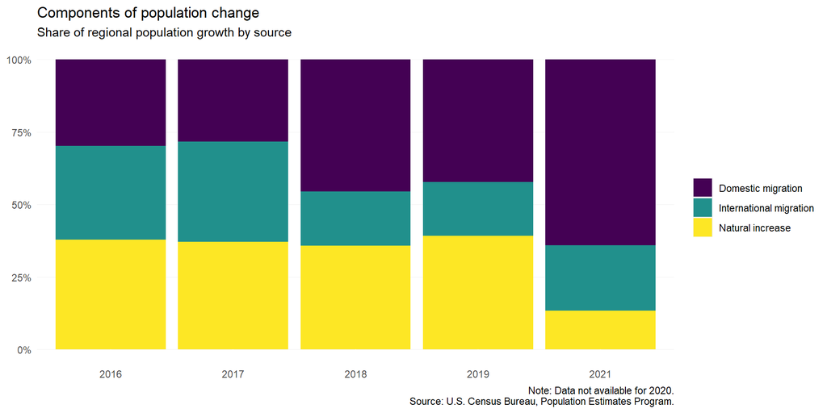

## Young adults are shacking up.

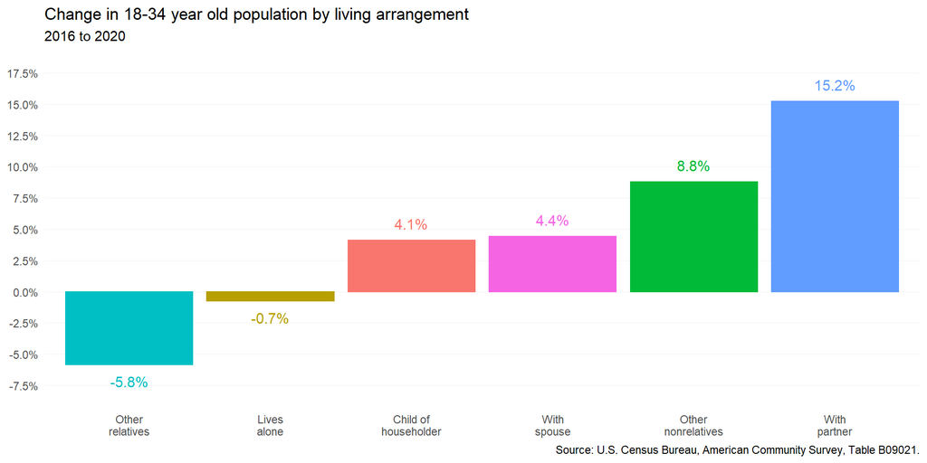

## Lowest-payed workers saw the biggest (relative) pay bumps.

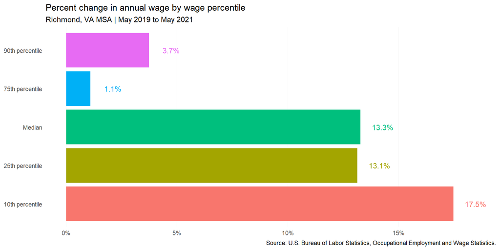

# Housing supply and market changes

## Racial homeownership gaps remain the status quo.

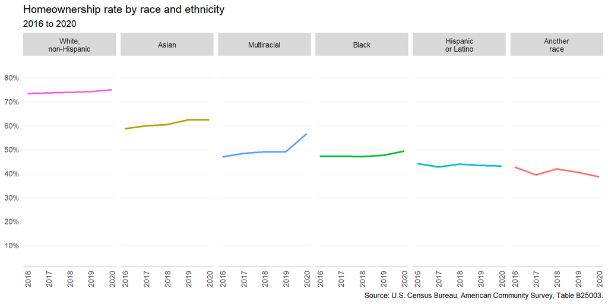

# Gap analysis

# Local summaries

## Richmond City

## Chesterfield County

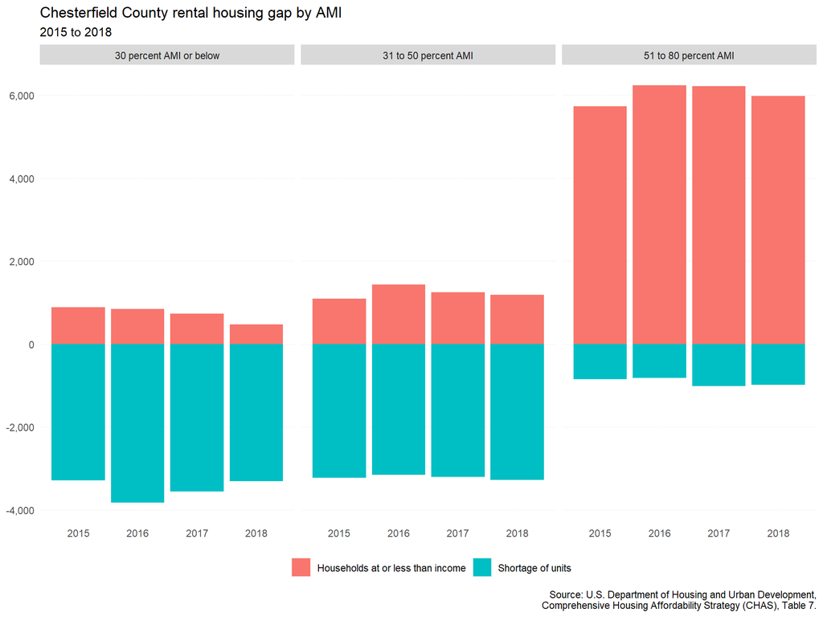

- In 2018, there was a shortage of 7,569 rental units for households below 80% AMI
- Greatest need in the county has been among households below 50% AMI
- But the need for rental at the higher end has been increasing (15% increase)

## Hanover County

## Henrico County

## Richmond City

## Next steps

- Feedback from PHA Board and staff
- Complete final updates on report (incorporating edits and suggestions)
- Consistent branding and visualizations
- Provide updates to data based on timing